# AIBBC 2025 Bioinformatics and Genomics Workshop Prediction Challenge

Farhad Zamani

Last update: 2025-10-22 11:31:25.999677

# Prediction Challenge! of the AIBBC 2025 Bioinformatics and Genomics

## Load library and data

```r
library(tidyverse)
library(tidymodels)
df_train <- read_rds(file = "~/Documents/AIBBC_2025/Challenge/Data/tcga_train.rds")
df_test <- read_rds(file = "~/Documents/AIBBC_2025/Challenge/Data/tcga_test.rds")
```

## Quick view of all data

```r
# Check the data dimension
dim(df_train)
```

```
## [1] 4275 4002
```

```r
dim(df_test)
```

```
## [1] 1426 4002
```

```r
df_train[1:10, 1:10]
```

```
##                              response  tissue KRTAP10-1 TRIM48 NKX2-4 KRTAP6-3
## TCGA-C8-A3M7-01A-12R-A21T-07    Tumor  Breast         0      0      0        0
## TCGA-FV-A23B-11A-11R-A16W-07   Normal   Liver         0      0      0        0
## TCGA-BH-A0DK-01A-21R-A056-07    Tumor  Breast         0      0      0        0
## TCGA-2Z-A9JM-01A-12R-A42S-07    Tumor  Kidney         0      0     64        0
## TCGA-94-8035-01A-11R-2247-07    Tumor    Lung         0      0      0        0
## TCGA-NI-A4U2-01A-11R-A28V-07    Tumor   Liver         0      0      0        0
## TCGA-BR-6457-01A-21R-1802-13    Tumor Stomach         0      0      0        0
## TCGA-D8-A27H-01A-11R-A16F-07    Tumor  Breast         0     33      1        0
## TCGA-DJ-A2QC-01A-11R-A18C-07    Tumor Thyroid         0      0      0        0
## TCGA-EM-A1YB-01A-11R-A14Y-07    Tumor Thyroid         0      0      0        0
##                              KRTAP9-2 SPRR4 OR8K1 KRTAP12-1
## TCGA-C8-A3M7-01A-12R-A21T-07        0     0     0         0
## TCGA-FV-A23B-11A-11R-A16W-07        0     0     0         0
## TCGA-BH-A0DK-01A-21R-A056-07        0     0     0         0
## TCGA-2Z-A9JM-01A-12R-A42S-07        0     0     0         0
## TCGA-94-8035-01A-11R-2247-07        2   915     0         1
## TCGA-NI-A4U2-01A-11R-A28V-07        0     0     0         0
## TCGA-BR-6457-01A-21R-1802-13        0     0     0         0
## TCGA-D8-A27H-01A-11R-A16F-07        0     0     0         0
## TCGA-DJ-A2QC-01A-11R-A18C-07        0     0     0         0
## TCGA-EM-A1YB-01A-11R-A14Y-07        0     0     0         0
```

```r
df_test[1:10, 1:10]
```

```
##                              response tissue KRTAP10-1 TRIM48 NKX2-4 KRTAP6-3
## TCGA-CJ-4876-01A-01R-1305-07     <NA>   <NA>         0      1      0        0
## TCGA-AO-A0J8-01A-21R-A034-07     <NA>   <NA>         3      0      0        0
## TCGA-FV-A2QR-01A-11R-A213-07     <NA>   <NA>         0      0      0        0
## TCGA-95-7944-01A-11R-2187-07     <NA>   <NA>         0      0      0        0
## TCGA-EJ-7794-01A-11R-2118-07     <NA>   <NA>         0      0      0        0
## TCGA-E2-A1LH-01A-11R-A14D-07     <NA>   <NA>         0      0      0        0
## TCGA-AC-A4ZE-01A-11R-A41B-07     <NA>   <NA>         0      0      0        0
## TCGA-P3-A6SW-01A-11R-A34R-07     <NA>   <NA>         0      0      0        0
## TCGA-34-5928-01A-11R-1820-07     <NA>   <NA>         0      1     29        0
## TCGA-CV-7177-01A-11R-2016-07     <NA>   <NA>         0      0      0        0
##                              KRTAP9-2 SPRR4 OR8K1 KRTAP12-1
## TCGA-CJ-4876-01A-01R-1305-07        0     0     0         0
## TCGA-AO-A0J8-01A-21R-A034-07        0     0     0         0
## TCGA-FV-A2QR-01A-11R-A213-07        0     0     0         0
## TCGA-95-7944-01A-11R-2187-07        0     0     0         0
## TCGA-EJ-7794-01A-11R-2118-07        0     0     0         0
## TCGA-E2-A1LH-01A-11R-A14D-07        0     0     0         0
## TCGA-AC-A4ZE-01A-11R-A41B-07        0     0     0         0
## TCGA-P3-A6SW-01A-11R-A34R-07        0    18     0         0
## TCGA-34-5928-01A-11R-1820-07        0     2     0         1
## TCGA-CV-7177-01A-11R-2016-07        0   604     0         0
```

You will see that `df_test$response` and `df_test$tissue` column is `NA`.

The aim of this challenge is to predict:

1. “**response”,** whether the sample comes from Tumor or Normal tissue, and
2. “**tissue**”, of which the sample comes from.

### We will provide you a backbone for this challenge!

## Better overview using PCA plot

```r
df_all <- rbind(df_train, df_test)
df_exp_only <- subset(df_all, select = -c(response, tissue))
```

```r
df_pca_only <- prcomp(df_exp_only, scale=TRUE)
```

```r
df_pca_all <- augment(df_pca_only, subset(df_all, select = c(response, tissue)))
df_pca_all <- column_to_rownames(df_pca_all, var = ".rownames")
```

### Plot the PCA

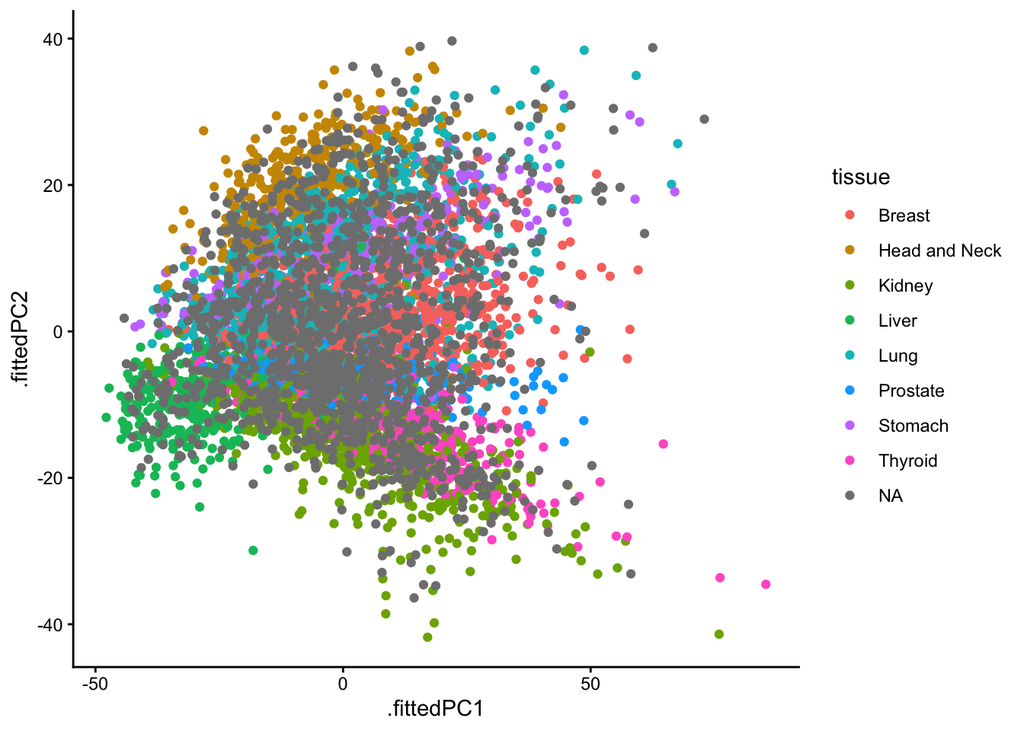

```r
df_pca_all %>%
  ggplot(aes(x=.fittedPC1, y=.fittedPC2)) +
    geom_point(aes(colour = tissue)) +
    theme_classic()
```

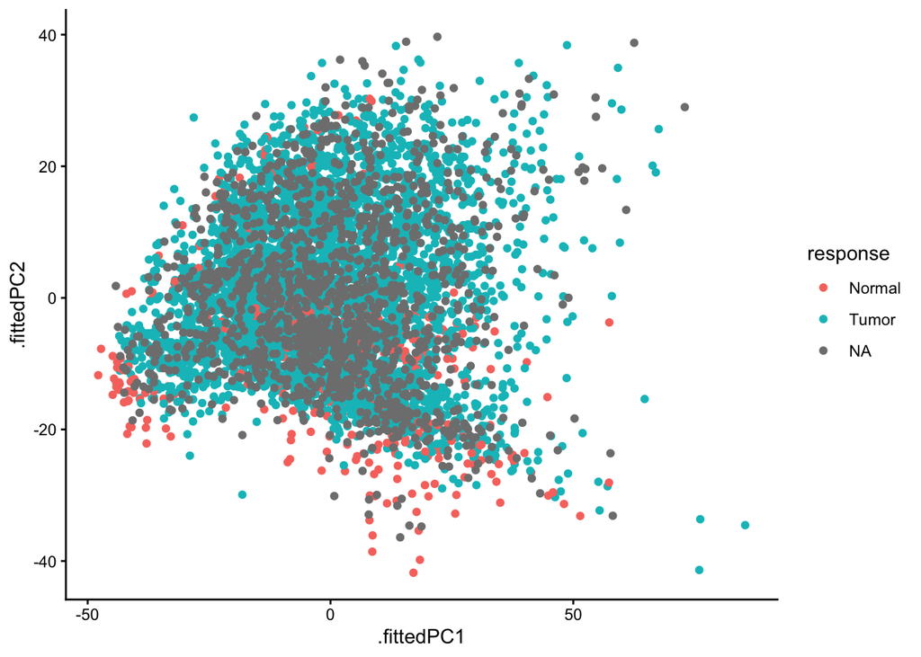

```r
df_pca_all %>%
  ggplot(aes(x=.fittedPC1, y=.fittedPC2)) +
    geom_point(aes(colour = response)) +
    theme_classic()
```

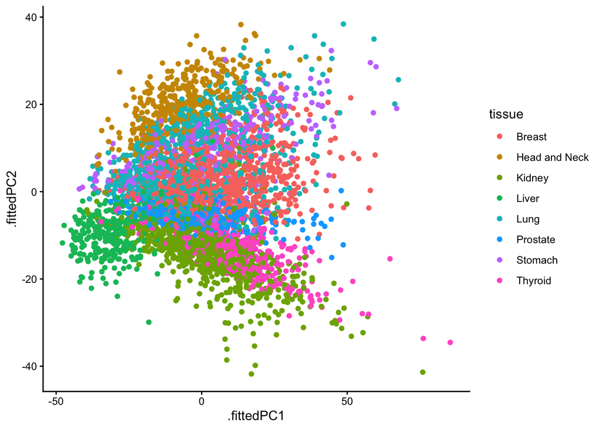

```r
df_pca_all %>%
  filter(!is.na(response)) %>%
  ggplot(aes(x=.fittedPC1, y=.fittedPC2)) +
    geom_point(aes(colour = tissue)) +
    theme_classic()
```

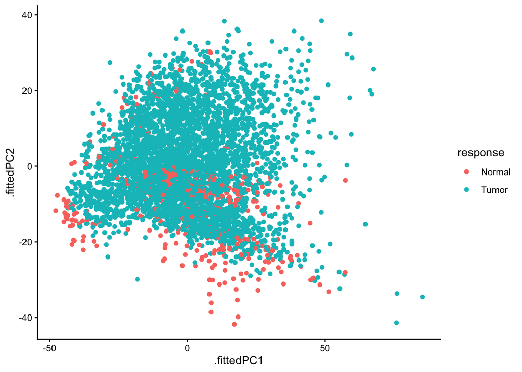

```r
df_pca_all %>%
  filter(!is.na(response)) %>%
  ggplot(aes(x=.fittedPC1, y=.fittedPC2)) +
    geom_point(aes(colour = response)) +
    theme_classic()
```

What do you think about these plots?